# GDR EcoStats - CiSStats 2019

## Galaxy Bricks : une plateforme d’analyse de données collaborative

Simon Bénateau, Sébastien Turpin, Yvan Le Bras

Les sciences participatives ont pour objectif historique le recueil de données. La plateforme "Galaxy-Bricks" contribue à l'élargissement du champ d'action de celles-ci en offrant la possibilité aux participants de prendre part à l'analyse de données. La possibilité de comprendre comment les chercheurs analysent les données et de participer à ces analyses devrait susciter de nouveaux modes de collaboration entre la recherche et les citoyens. Les outils de partage de résultats, d'outils, de workflow et de rapport que propose "Galaxy-E" couplés au cadre de formation proposés par le réseau "Galaxy training material" permettent d'atteindre ces objectifs.

## Galaxy Ecology : Une plateforme d'analyse de données accessible.

Simon Bénateau, Benjamin Yguel, Alan Amossé, Sébastien Turpin, Yvan Le Bras

## Vigie nature

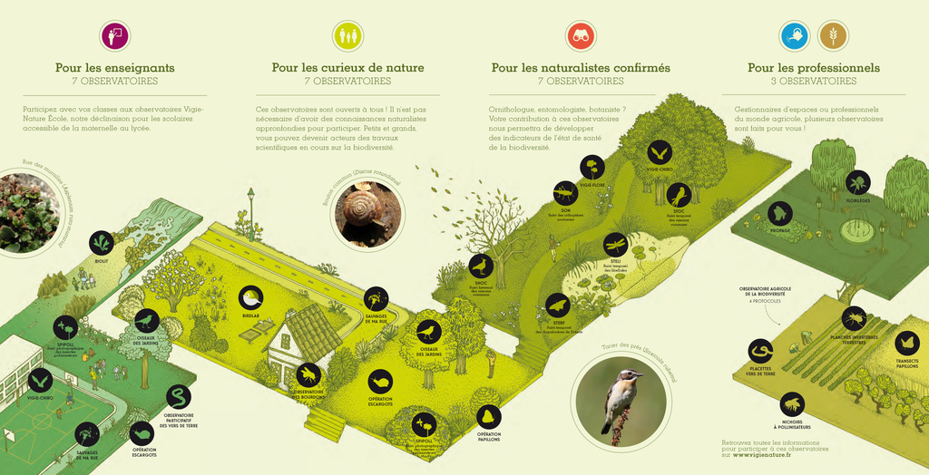

## Organisation du réseau d'acteur

## La place de l'analyse de données et de la production d'indicateurs

## Demandes de la communautés et freins à l'implémentation

- Dépendances (versions des packages)
- Lignes de commande (utilisation de R)

## Perspective

FAIR

- Tutoriels

L'analyse des données issues des obervatoires de scicences participatives nécessite l'emploi d'outils statistiques pointus qui requièrent des compétences en programmation. Ces dernières peuvent représenter un obstacle à l'apprentissage ou à l'utilisation d'outils par certains acteurs de la communautés des sciences participatives. La plateforme galaxy-E permet de développer des outils avec une interface graphique, gérant les dépendances et la reproductibilité des analyses. Elle facilite l'accès à ces outils pour les acteurs des sciences participatives qui analysent les données et produisent des indicateurs.